# Good plot - Bad plot

Kirill Musaev

3/19/2021

# Load Libraries

- “Tidyverse” for formatting
- “Here” for file management

```r
library(tidyverse)
library(here)
```

# Load Data

- From file
- Includes a command to glimpse at the data in the end

```r
FullData<-read_csv(here("good_plot-bad_plot","data","ikea.csv")) #load data from file path
#glimpse(FullData) #check data loading
```

# Select and filter data

- Create a data frame with only the data to be processed
- Filter out incomplete rows
- Includes a command to view the data in the end

```r
CleanData<-FullData %>%
  select(price, depth, height, width)%>% #delete unnecessary columns
  filter(complete.cases(.)) #remove incomplete rows
#view(CleanData) #check data
```

# Process data

- Calculate the volume of the item in each row
- Convert the original prices in Saudi Riyals to USD using the conversion rate on 4/20/2020, the day the data was generated. Reference: https://www.exchange-rates.org/Rate/USD/SAR/4-20-2020
- Includes a command to view the data in the end

```r
DataWVolume <- CleanData %>% #create pipeline for calculations
  mutate(volume = depth * height * width) %>% #calculate volume
  mutate(price = price / 3.7545) #convert currency

#view(DataWVolume) #check data
```

# Generate bad plot

- Low resolution
- Undescriptive title
- Title does not fit in the image
- Axes labels useless, no units
- Y axis coordinates in an inconvenient notation
- “Independent” variable on vertical axis
- Box plot not appropriate for data that is continuous on both axes, effectively eliminating the x axis
- Regression line is linear while one of the axes is logarithmic
- Regression line color blends in with the background

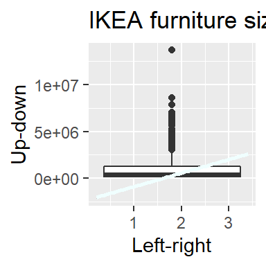

```r
DataWVolume %>% #pipeline for ggplot
  ggplot(aes(x = log10(price), #x axis irrelevant
             y = volume) #"independent" variable on y axis
  ) +
  geom_boxplot() + #graph type discontinuous on x axis
  geom_smooth(method = "lm", #regression line linear on a log graph
              colour = "azure") + #color blends in with the background
  labs(x = "Left-right",#useless labels
       y = "Up-down",
       title = "IKEA furniture size and price"
       )
```

```r
ggsave(here("good_plot-bad_plot","Output","Bad_plot.jpg"),#save plot to file
       width = 1.5, height = 1.5) #set aspect ratio
```

# Generate good plot

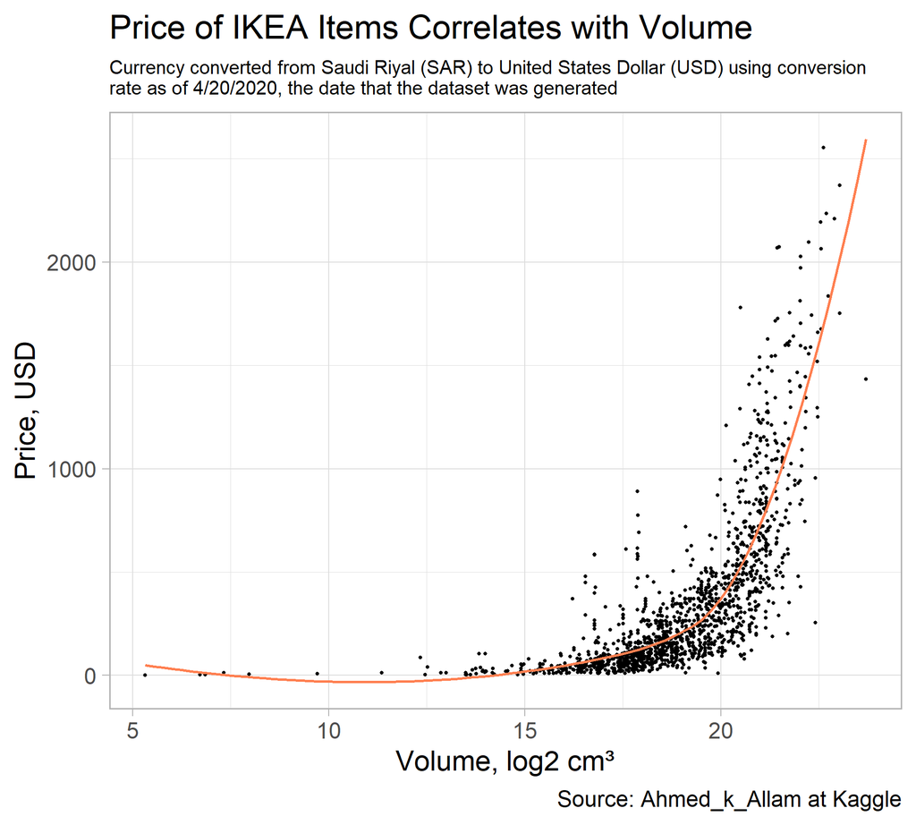

```r
DataWVolume %>% #pipeline for ggplot
  ggplot(aes(x = log2(volume), #set x axis to volume and apply logarithmic scale
             y = price #set y axis to price
             )
         ) +
  geom_point(size = 1) + # set size for individual data points
  geom_smooth(method = "loess", #create regression line using local fitting
              se = FALSE, #remove confidence intervals since they are not rendered correctly on log scale
              colour = "coral") + #set color for regression line
  labs(x = "Volume, log₂ cm³",#set x axis label.Note that "₂" did not render as a subscript on the plot
       y = "Price, USD", #y axis label
       title = "Price of IKEA Items Correlates with Volume", #add title
       subtitle = "Currency converted from Saudi Riyal (SAR) to United States Dollar (USD) using conversion \nrate as of 4/20/2020, the date that the dataset was generated", #add subtitle
       caption = "Source: Ahmed_k_Allam at Kaggle" #indicate source under the graph
       )+
  theme_light(base_size = 22) + #set a theme
  theme(plot.subtitle = element_text(size = 15)) #set size for subtitle
```

```r
ggsave(here("good_plot-bad_plot","Output","Good_plot.jpg"),#save plot to file
       width = 10, height = 9) #set aspect ratio
```